# Chapter 3. Logistic regression

Today is:

```
## [1] "Thu Nov 12 23:10:55 2020"
```

#### Task 1. If you see this, hence task 1 is done.

#### Task 2. Read and explore the data.

I made my own data set, but mess provided by course organizers made me fill uncomfortable to use it. I did not get clear answer [here](https://mooc.helsinki.fi/mod/forum/discuss.php?d=21108#p50025), so I will use provided by Reijo Sund data code. At least points are not interesting for me anymore. Feel free to cut them down =D

Reading the data.

```r
alc <- read.csv("https://github.com/rsund/IODS-project/raw/master/data/alc.csv")
```

The data derived from [public UCI repository](https://archive.ics.uci.edu/ml/datasets/Student+Performance). The data approach student achievement in secondary education measured in two Portuguese schools. Students performance was measured in to classes: Portuguese language and Math. Additional to personal information and Grades data has information about alcohol consumption of students. Data has no personal data and was merged using set of columns. Duplicated “unique” columns were deleted.

Data dimension:

```
## [1] 370  51
```

```
##   school sex age address famsize Pstatus Medu Fedu     Mjob     Fjob     reason
## 1     GP   F  15       R     GT3       T    1    1  at_home    other       home
## 2     GP   F  15       R     GT3       T    1    1    other    other reputation
## 3     GP   F  15       R     GT3       T    2    2  at_home    other reputation
## 4     GP   F  15       R     GT3       T    2    4 services   health     course
## 5     GP   F  15       R     GT3       T    3    3 services services reputation
## 6     GP   F  15       R     GT3       T    3    4 services   health     course
##   guardian traveltime studytime schoolsup famsup activities nursery higher
## 1   mother          2         4       yes    yes        yes     yes    yes
## 2   mother          1         2       yes    yes         no      no    yes
## 3   mother          1         1       yes    yes        yes     yes    yes
## 4   mother          1         3       yes    yes        yes     yes    yes
## 5    other          2         3        no    yes        yes     yes    yes
## 6   mother          1         3       yes    yes        yes     yes    yes
##   internet romantic famrel freetime goout Dalc Walc health n id.p id.m failures
```

[output cut: 20 more lines]

#### Task 3. Choose and hypothesize variables.

From variables above I will choose: 1) famrel 2) activities 3) address 4) higher Let’s put ideas on the paperer now. **1)famrel** - quality of family relationships. This is quit trivial and common to blame family. So why not to do as STM wants. We always assume that bad climate could cause problems with alcohol and drugs. But, I don’t think bad family climate has negative impact. **2)activities** - extra-curricular activities. I suppose that busy or interested person has less time and willing to consume alcohol. At least no time to be drunk. Thus, less consumption. Need to check. **3)address** - type of home address. The stereotype will be that people from rural area drinking more. I think oposite youngsters in urban area have more ability to get and drink alcohol. Let’s check that out. **4)higher** - wants to take higher education This is obvious. Person interested in self-development potentially has less time and willing to drink.

#### Task 4. Explore the data.

```r
choosen<-c("famrel","activities","address","higher","high_use","alc_use")
my_alc<-select(alc,(one_of(choosen)))
my_alc %>% group_by(famrel,high_use) %>% summarise(count = n())
```

```
## # A tibble: 10 x 3
## # Groups:   famrel [5]
##    famrel high_use count
##     <int> <lgl>    <int>
##  1      1 FALSE        6
##  2      1 TRUE         2
##  3      2 FALSE        9
##  4      2 TRUE         9
##  5      3 FALSE       39
##  6      3 TRUE        25
##  7      4 FALSE      128
##  8      4 TRUE        52
##  9      5 FALSE       77
## 10      5 TRUE        23
```

Most of students are from families with good (4) and perfect (5) relationships. Percent of drinkers is higher in good familiear compare to perfect ones. Close to equal in families with rating 2 and 3.

```r
my_alc %>% group_by(address,high_use) %>% summarise(count = n())
```

```
## # A tibble: 4 x 3
## # Groups:   address [2]
##   address high_use count
##   <chr>   <lgl>    <int>
## 1 R       FALSE       50
## 2 R       TRUE        31
## 3 U       FALSE      209
## 4 U       TRUE        80
```

I would rather say that percent of student in rural area (38%) is higher than in Urban (28%).

```r
my_alc %>% group_by(activities,high_use) %>% summarise(count = n())
```

```
## # A tibble: 4 x 3
## # Groups:   activities [2]
##   activities high_use count
##   <chr>      <lgl>    <int>
## 1 no         FALSE      120
## 2 no         TRUE        59
## 3 yes        FALSE      139
## 4 yes        TRUE        52
```

Looks like same amount of students consuming a lot of alcohol in no and yes cases. In other words activities has no impact.

```r
my_alc %>% group_by(higher,high_use) %>% summarise(count = n())
```

```
## # A tibble: 4 x 3
## # Groups:   higher [2]
##   higher high_use count
##   <chr>  <lgl>    <int>
## 1 no     FALSE        7
## 2 no     TRUE         9
## 3 yes    FALSE      252
## 4 yes    TRUE       102
```

Let’s see the distribution (bar) plots.

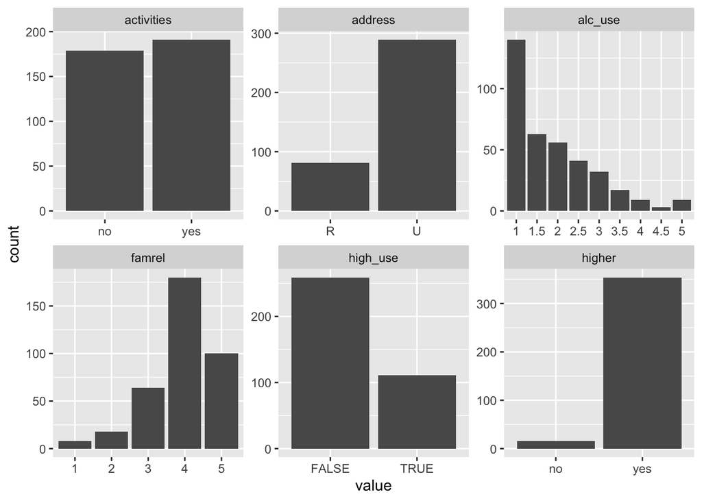

```r
gather(my_alc) %>% ggplot(aes(value)) + facet_wrap("key", scales = "free")+geom_bar()
```

#### Task 5. LOGistic regression.

First let’s fit logistic regression model and print summary.

```r
model<- glm(high_use ~ address+activities+ famrel+higher-1, data = my_alc, family = "binomial")
summary(model)
```

```
##
## Call:
## glm(formula = high_use ~ address + activities + famrel + higher -
##     1, family = "binomial", data = my_alc)
##
## Deviance Residuals:
##     Min       1Q   Median       3Q      Max
## -1.4563  -0.8169  -0.7402   1.3058   1.8123
##
## Coefficients:
##               Estimate Std. Error z value Pr(>|z|)
## addressR        1.6812     0.7225   2.327   0.0200 *
## addressU        1.2019     0.7005   1.716   0.0862 .
## activitiesyes  -0.2286     0.2342  -0.976   0.3291
## famrel         -0.2724     0.1239  -2.199   0.0279 *
## higheryes      -1.0383     0.5260  -1.974   0.0484 *
## ---
## Signif. codes:  0 '***' 0.001 '**' 0.01 '*' 0.05 '.' 0.1 ' ' 1
##
## (Dispersion parameter for binomial family taken to be 1)
##
##     Null deviance: 512.93  on 370  degrees of freedom
## Residual deviance: 438.13  on 365  degrees of freedom
## AIC: 448.13
##
## Number of Fisher Scoring iterations: 4
```

I added -1 to see effect of Rural address instead of Intercept. From model we could see that Rural address has statistical relationship with alcohol consumption. Both Rural and Urban areas has positive coefficient, but it is smaller in Urban area. Family relationship and want to have higher education variable’s also have statistical link and negative coefficient.

I don’t understand why I could not see activitiesno and higherno variables in table. But, if one would crate model with activities only, he/she well get sudden significance which was not the case before. I can show:

```r
idiotic_model<-glm(formula = high_use ~ activities - 1, family = "binomial", data = my_alc)
summary(idiotic_model)
```

```
##
## Call:
## glm(formula = high_use ~ activities - 1, family = "binomial",
##     data = my_alc)
##
## Deviance Residuals:
##     Min       1Q   Median       3Q      Max
## -0.8943  -0.8943  -0.7972   1.4899   1.6131
##
## Coefficients:
##               Estimate Std. Error z value Pr(>|z|)
## activitiesno   -0.7100     0.1590  -4.465 8.01e-06 ***
## activitiesyes  -0.9832     0.1626  -6.049 1.46e-09 ***
## ---
## Signif. codes:  0 '***' 0.001 '**' 0.01 '*' 0.05 '.' 0.1 ' ' 1
##
## (Dispersion parameter for binomial family taken to be 1)
##
##     Null deviance: 512.93  on 370  degrees of freedom
## Residual deviance: 450.59  on 368  degrees of freedom
## AIC: 454.59
##
## Number of Fisher Scoring iterations: 4
```

Make odds ratio.

```r
OR <- coef(model) %>% exp
CI<-confint(model)%>%exp
cbind(OR, CI)
```

```
##                      OR     2.5 %     97.5 %
## addressR      5.3717313 1.3171301 22.8034908
## addressU      3.3264809 0.8481833 13.4937683
## activitiesyes 0.7956502 0.5019263  1.2592797
## famrel        0.7615264 0.5964673  0.9712265
## higheryes     0.3540559 0.1216519  0.9916501
```

I will read this [material](https://www.ncbi.nlm.nih.gov/pmc/articles/PMC5253299/), but not yet. Course information is limited and I did not get how to interpret table above. Only self study.

#### Task 6. Prediction.

Let’s fit the prediction model similar to presented in DataCamp

```r
probabilities <- predict(model, type = "response")
my_alc <- mutate(my_alc, probability = probabilities)
my_alc <- mutate(my_alc, prediction = (probability > 0.5))
table(high_use = my_alc$high_use, prediction = my_alc$prediction)
```

```
##         prediction
## high_use FALSE TRUE
##    FALSE   253    6
##    TRUE    101   10
```

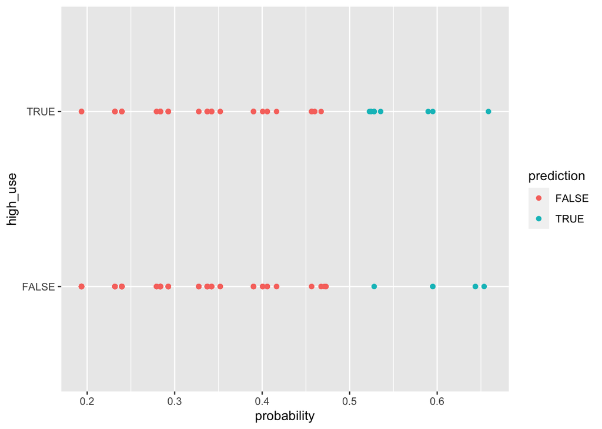

```r
g3 <- ggplot(my_alc, aes(x = probability, y = high_use,col=prediction))
g3+geom_point()
```

```r
loss_func <- function(class, prob) {
  n_wrong <- abs(class - prob) > 0.5
  mean(n_wrong)
}

loss_func(class = my_alc$high_use, prob = my_alc$probability)
```

```
## [1] 0.2891892
```

I will not perform task 7 and 8, just will say that we actively using modified cross-validation while choosing model to predict breeding value of farm animals in our customer projects.